# Biostat 212a Homework 1

## 4 ISL Exercise 2.4.10 (30% pts)

This exercise involves the `Boston` housing data set.

1. To begin, load in the Boston data set. The Boston data set is part of the ISLR2 library in R. How many rows are in this data set? How many columns? What do the rows and columns represent?

Your can read in the `boston` data set directly from url https://raw.githubusercontent.com/ucla-biostat-212a/2024winter/master/slides/data/Boston.csv. A documentation of the `boston` data set is [here](https://www.rdocumentation.org/packages/ISLR2/versions/1.3-2/topics/Boston).

**R**

```r
library(tidyverse)
library(ISLR2)

Boston <- read_csv("https://raw.githubusercontent.com/ucla-biostat-212a/2024winter/master/slides/data/Boston.csv", col_select = -1) %>%
  print(width = Inf)
```

```
# A tibble: 506 × 13
      crim    zn indus  chas   nox    rm   age   dis   rad   tax ptratio lstat
     <dbl> <dbl> <dbl> <dbl> <dbl> <dbl> <dbl> <dbl> <dbl> <dbl>   <dbl> <dbl>
 1 0.00632  18    2.31     0 0.538  6.58  65.2  4.09     1   296    15.3  4.98
 2 0.0273    0    7.07     0 0.469  6.42  78.9  4.97     2   242    17.8  9.14
 3 0.0273    0    7.07     0 0.469  7.18  61.1  4.97     2   242    17.8  4.03
 4 0.0324    0    2.18     0 0.458  7.00  45.8  6.06     3   222    18.7  2.94
 5 0.0690    0    2.18     0 0.458  7.15  54.2  6.06     3   222    18.7  5.33
 6 0.0298    0    2.18     0 0.458  6.43  58.7  6.06     3   222    18.7  5.21
 7 0.0883   12.5  7.87     0 0.524  6.01  66.6  5.56     5   311    15.2 12.4
 8 0.145    12.5  7.87     0 0.524  6.17  96.1  5.95     5   311    15.2 19.2
 9 0.211    12.5  7.87     0 0.524  5.63 100    6.08     5   311    15.2 29.9
10 0.170    12.5  7.87     0 0.524  6.00  85.9  6.59     5   311    15.2 17.1
    medv
   <dbl>
 1  24
 2  21.6
 3  34.7
 4  33.4
 5  36.2
 6  28.7
 7  22.9
 8  27.1
 9  16.5
10  18.9
# ℹ 496 more rows
```

```r
Boston
```

```
# A tibble: 506 × 13
      crim    zn indus  chas   nox    rm   age   dis   rad   tax ptratio lstat
     <dbl> <dbl> <dbl> <dbl> <dbl> <dbl> <dbl> <dbl> <dbl> <dbl>   <dbl> <dbl>
 1 0.00632  18    2.31     0 0.538  6.58  65.2  4.09     1   296    15.3  4.98
 2 0.0273    0    7.07     0 0.469  6.42  78.9  4.97     2   242    17.8  9.14
 3 0.0273    0    7.07     0 0.469  7.18  61.1  4.97     2   242    17.8  4.03
 4 0.0324    0    2.18     0 0.458  7.00  45.8  6.06     3   222    18.7  2.94
 5 0.0690    0    2.18     0 0.458  7.15  54.2  6.06     3   222    18.7  5.33
 6 0.0298    0    2.18     0 0.458  6.43  58.7  6.06     3   222    18.7  5.21
 7 0.0883   12.5  7.87     0 0.524  6.01  66.6  5.56     5   311    15.2 12.4
 8 0.145    12.5  7.87     0 0.524  6.17  96.1  5.95     5   311    15.2 19.2
 9 0.211    12.5  7.87     0 0.524  5.63 100    6.08     5   311    15.2 29.9
10 0.170    12.5  7.87     0 0.524  6.00  85.9  6.59     5   311    15.2 17.1
# ℹ 496 more rows
# ℹ 1 more variable: medv <dbl>
```

**Python**

```python
import pandas as pd
import io
import requests

url = "https://raw.githubusercontent.com/ucla-econ-425t/2023winter/master/slides/data/Boston.csv"
s = requests.get(url).content
Boston = pd.read_csv(io.StringIO(s.decode('utf-8')), index_col = 0)
Boston
```

```
        crim    zn  indus  chas    nox  ...  rad  tax  ptratio  lstat  medv
1    0.00632  18.0   2.31     0  0.538  ...    1  296     15.3   4.98  24.0
2    0.02731   0.0   7.07     0  0.469  ...    2  242     17.8   9.14  21.6
3    0.02729   0.0   7.07     0  0.469  ...    2  242     17.8   4.03  34.7
4    0.03237   0.0   2.18     0  0.458  ...    3  222     18.7   2.94  33.4
5    0.06905   0.0   2.18     0  0.458  ...    3  222     18.7   5.33  36.2
..       ...   ...    ...   ...    ...  ...  ...  ...      ...    ...   ...
502  0.06263   0.0  11.93     0  0.573  ...    1  273     21.0   9.67  22.4
503  0.04527   0.0  11.93     0  0.573  ...    1  273     21.0   9.08  20.6
504  0.06076   0.0  11.93     0  0.573  ...    1  273     21.0   5.64  23.9
505  0.10959   0.0  11.93     0  0.573  ...    1  273     21.0   6.48  22.0
506  0.04741   0.0  11.93     0  0.573  ...    1  273     21.0   7.88  11.9

[506 rows x 13 columns]
```

**Solution** There are 506 rows and 13 columns in this dataset. Each row in this dataset represent a house, and each column represent a property of the house. Description of the data columns are:

- `CRIM` - per capita crime rate by town
- `ZN` - proportion of residential land zoned for lots over 25,000 sq.ft.
- `INDUS` - proportion of non-retail business acres per town.
- `CHAS` - Charles River dummy variable (1 if tract bounds river; 0 otherwise)
- `NOX` - nitric oxides concentration (parts per 10 million)
- `RM` - average number of rooms per dwelling
- `AGE` - proportion of owner-occupied units built prior to 1940
- `DIS` - weighted distances to five Boston employment centres
- `RAD` - index of accessibility to radial highways
- `TAX` - full-value property-tax rate per $10,000
- `PTRATIO` - pupil-teacher ratio by town
- `LSTAT` - % lower status of the population
- `MEDV` - Median value of owner-occupied homes in $1000’s
2. Make some pairwise scatterplots of the predictors (columns) in this data set. Describe your findings.

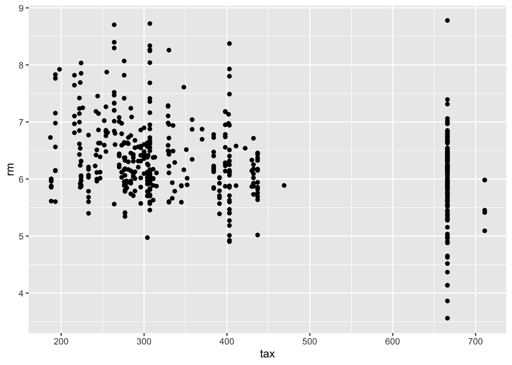

   ```r
   library(ggplot2)

   ggplot(Boston, aes(tax, rm)) +
     geom_point()
   ```

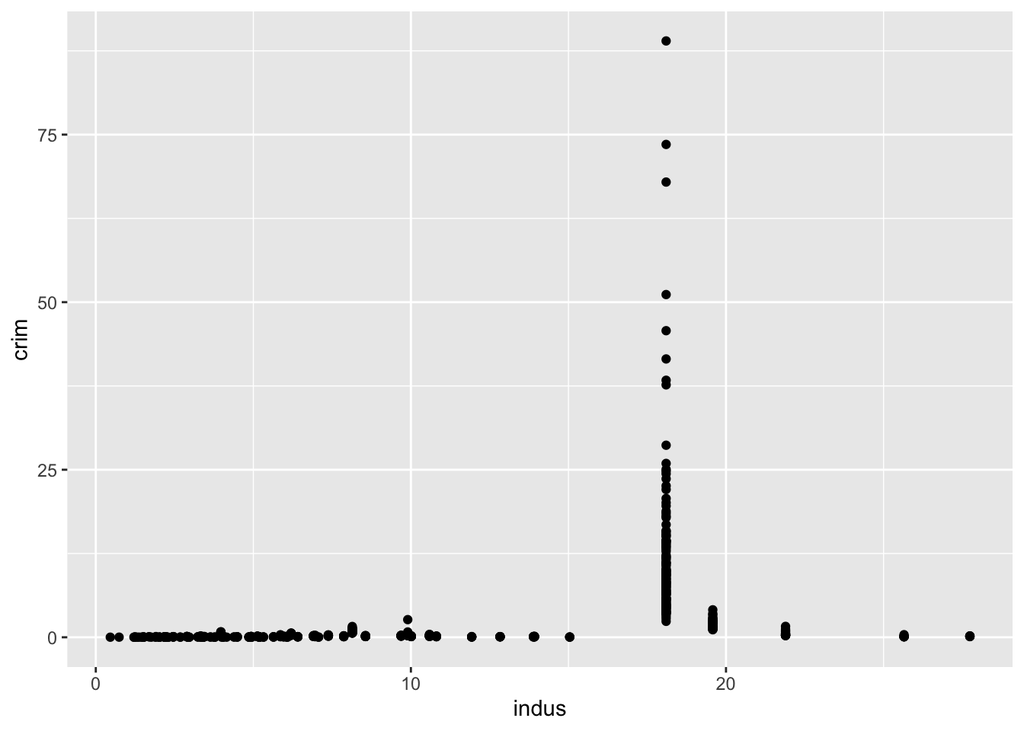

   ```r
   ggplot(Boston, aes(indus, crim)) +
     geom_point()
   ```

   **Solution** From the scatterplot between `tax` (full-value property-tax rate per $10,000) and `rm` (average number of rooms), we can observe that the house that have less property-tax rate per $10,000 usually have more rooms. And from the scatterplot between `crim` (crime rate) and `indus` (proportion of non-retail business per acres per town), we can see that the high crime rate are associated with a particular `indus` level (around 17-18), which is quite interesting.
3. Are any of the predictors associated with per capita crime rate? If so, explain the relationship.

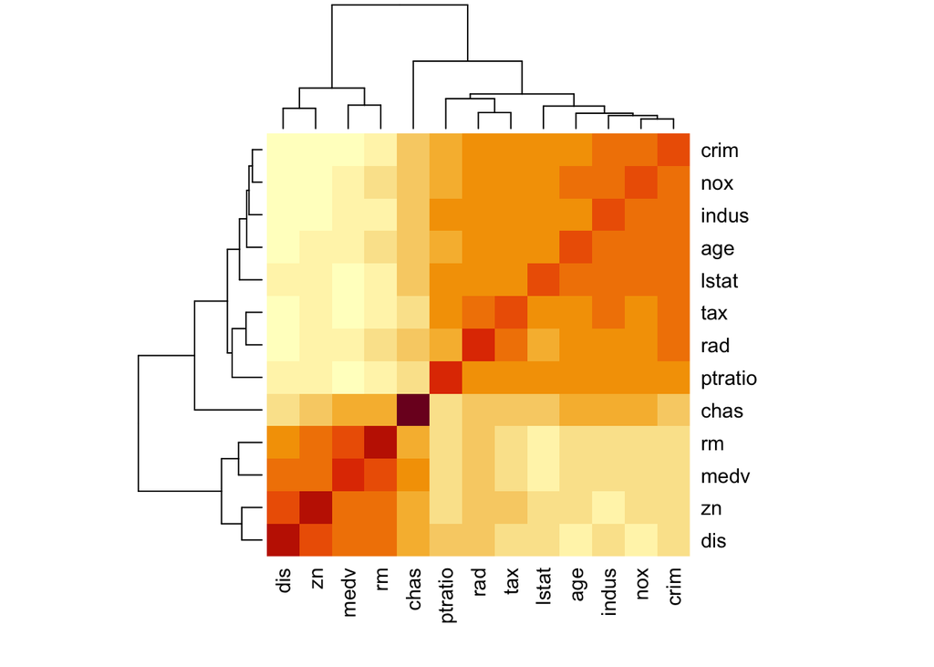

   ```r
   heatmap(cor(Boston, method = "spearman"), cexRow = 1.1, cexCol = 1.1)
   ```

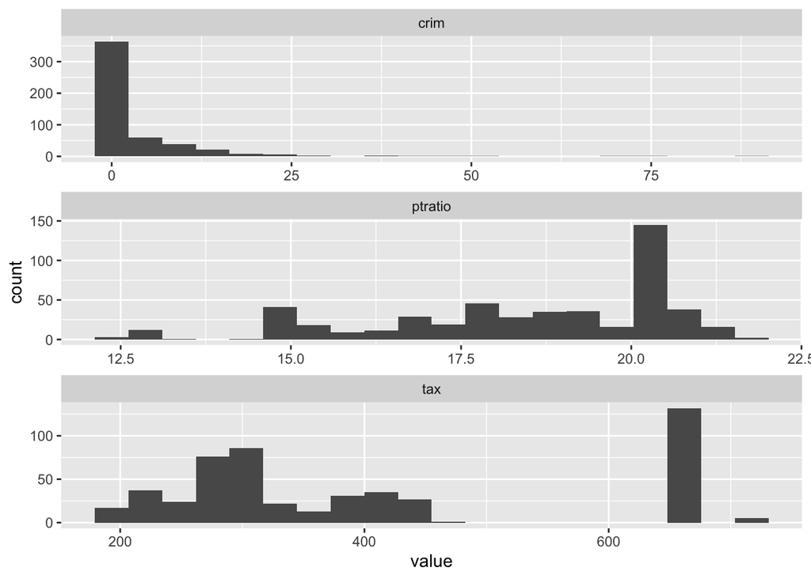

   ```r
   Boston |>
     pivot_longer(cols = 1:13) |>
     filter(name %in% c("crim", "tax", "ptratio")) |>
     ggplot(aes(value)) +
     geom_histogram(bins = 20) +
     facet_wrap(~name, scales = "free", ncol = 1)
   ```

   ```r
   table(Boston$chas)
   ```

   ```
     0   1
   471  35
   ```

6. What is the median pupil-teacher ratio among the towns in this data set?

   ```r
   median(Boston$ptratio)
   ```

   ```
   [1] 19.05
   ```

7. Which census tract of Boston has lowest median value of owner-occupied homes? What are the values of the other predictors for that census tract, and how do those values compare to the overall ranges for those predictors? Comment on your findings.

   ```r
   Boston <- data.frame("obs" = c(1:length(Boston$crim)), Boston)
   Boston %>%  filter(medv == min(medv))
   ```

   ```
     obs    crim zn indus chas   nox    rm age    dis rad tax ptratio lstat medv
   1 399 38.3518  0  18.1    0 0.693 5.453 100 1.4896  24 666    20.2 30.59    5
   2 406 67.9208  0  18.1    0 0.693 5.683 100 1.4254  24 666    20.2 22.98    5
   ```

   **Solution** The The above two census tracts have the lowest median value of 5 from the owner occupied homes.

   ```r
   summary(Boston[,2:14])
   ```

   ```
         crim                zn             indus            chas
    Min.   : 0.00632   Min.   :  0.00   Min.   : 0.46   Min.   :0.00000
    1st Qu.: 0.08205   1st Qu.:  0.00   1st Qu.: 5.19   1st Qu.:0.00000
    Median : 0.25651   Median :  0.00   Median : 9.69   Median :0.00000
    Mean   : 3.61352   Mean   : 11.36   Mean   :11.14   Mean   :0.06917
    3rd Qu.: 3.67708   3rd Qu.: 12.50   3rd Qu.:18.10   3rd Qu.:0.00000
    Max.   :88.97620   Max.   :100.00   Max.   :27.74   Max.   :1.00000
         nox               rm             age              dis
    Min.   :0.3850   Min.   :3.561   Min.   :  2.90   Min.   : 1.130
    1st Qu.:0.4490   1st Qu.:5.886   1st Qu.: 45.02   1st Qu.: 2.100
    Median :0.5380   Median :6.208   Median : 77.50   Median : 3.207
    Mean   :0.5547   Mean   :6.285   Mean   : 68.57   Mean   : 3.795
    3rd Qu.:0.6240   3rd Qu.:6.623   3rd Qu.: 94.08   3rd Qu.: 5.188
    Max.   :0.8710   Max.   :8.780   Max.   :100.00   Max.   :12.127
         rad              tax           ptratio          lstat
    Min.   : 1.000   Min.   :187.0   Min.   :12.60   Min.   : 1.73
    1st Qu.: 4.000   1st Qu.:279.0   1st Qu.:17.40   1st Qu.: 6.95
    Median : 5.000   Median :330.0   Median :19.05   Median :11.36
    Mean   : 9.549   Mean   :408.2   Mean   :18.46   Mean   :12.65
    3rd Qu.:24.000   3rd Qu.:666.0   3rd Qu.:20.20   3rd Qu.:16.95
    Max.   :24.000   Max.   :711.0   Max.   :22.00   Max.   :37.97
         medv
    Min.   : 5.00
    1st Qu.:17.02
    Median :21.20
    Mean   :22.53
    3rd Qu.:25.00
    Max.   :50.00
   ```

   - `crim`: The crime rates in both tracts are outliers, significantly higher than the median crime rate.
   - `zn`: Both tracts have zero proportion of land zoned for lots over 25,000 sq. ft., which matches the median value, suggesting minimal or no investment in these areas.
   - `indus`: The proportion of non-retail business acres is 18.1 for both tracts, exceeding the median and falling in the third quartile, indicating promising business opportunities.
   - `chas`: Neither tract is adjacent to the Charles River.
   - `nox`: Nitrogen oxide concentrations are above the third quartile, suggesting high levels of pollution, potentially due to proximity to highways.
   - `rm`: The average number of rooms per dwelling falls in the first quartile, indicating smaller homes.
   - `age`: The proportion of owner-occupied units built before 1940 is in the upper quartile, reflecting very old housing stock.
   - `dis`: The weighted average distance to five Boston employment centers is in the lower quartile, possibly indicating high unemployment.
   - `rad`: Both tracts have the maximum index for radial highway accessibility, implying close proximity to highways.
   - `tax`: Property tax rates per $10,000 are near the third quartile, indicating high taxes for smaller homes, suggesting a non-linear relationship between tax rates and housing size.
   - `ptratio`: The pupil-teacher ratio is near the third quartile, suggesting a relatively strong education system.
   - `lstat`: The proportion of the population in lower socioeconomic status is in the upper quartile, indicating a high concentration of low-income households.
8. In this data set, how many of the census tract average more than seven rooms per dwelling? More than eight rooms per dwelling? Comment on the census tracts that average more than eight rooms per dwelling.

   ```r
   seven_rooms_above = Boston %>% filter(rm > 7)
   eight_rooms_above = Boston %>% filter(rm > 8)
   data.frame("more_than_7_rooms" = c(length(seven_rooms_above$rm)),
              "more_than_8_rooms" = c(length(eight_rooms_above$rm)))
   ```

   ```
     more_than_7_rooms more_than_8_rooms
   1                64                13
   ```

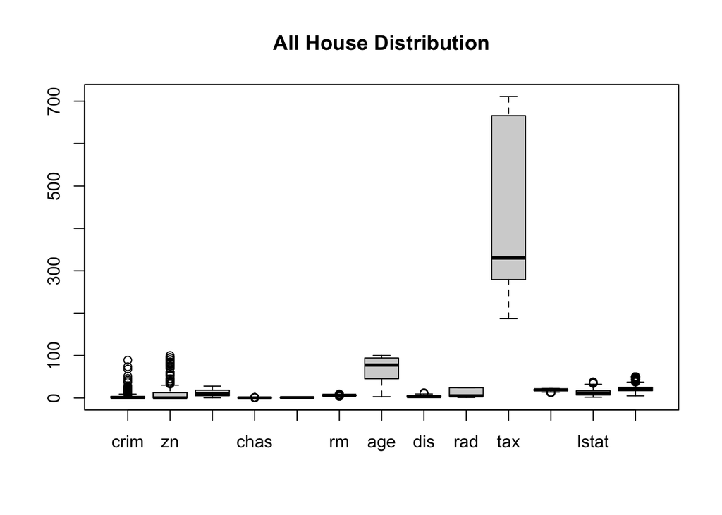

   ```r
   plot_all = boxplot(Boston[, 2:14], main="All House Distribution")
   ```

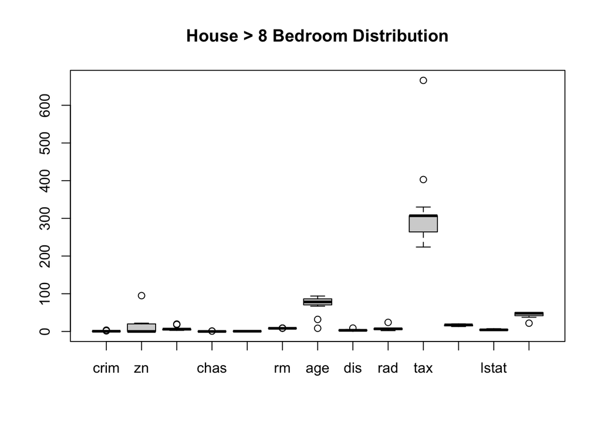

   ```r
   plot_eight = boxplot(eight_rooms_above[, 2:14], main="House > 8 Bedroom Distribution")
   ```

   **Solution** Comparing the box plot distribution between all houses and houses with more than eight bedrooms, the tax is generally lower and the crime rate are also lower for houses with more than 8 bedrooms.

## 5 ISL Exercise 3.7.3 (20% pts)

Suppose we have a data set with five predictors, $X_1$ = GPA, $X_2$ = IQ, $X_3$ = Level (1 for College and 0 for High School), $X_4$ = Interaction between GPA and IQ, and $X_5$ = Interaction between GPA and Level. The response is starting salary after graduation (in thousands of dollars). Suppose we use least squares to fit the model, and get $\hat\beta_0 = 50$, $\hat\beta_1 = 20$, $\hat\beta_2 = 0.07$, $\hat\beta_3 = 35$, $\hat\beta_4 = 0.01$, $\hat\beta_5 = -10$.

1. Which answer is correct, and why?
   1. For a fixed value of IQ and GPA, high school graduates earn more on average than college graduates.
   2. For a fixed value of IQ and GPA, college graduates earn more on average than high school graduates.
   3. For a fixed value of IQ and GPA, high school graduates earn more on average than college graduates provided that the GPA is high enough.
   4. For a fixed value of IQ and GPA, college graduates earn more on average than high school graduates provided that the GPA is high enough.

   **Solution** According to the given information, the model is

   $$y = \beta_0 + \beta_1 \cdot \text{GPA} + \beta_2 \cdot \text{IQ} + \beta_3 \cdot \text{Level} + \beta_4 \cdot \text{GPA} \cdot \text{IQ} + \beta_5 \cdot \text{GPA} \cdot \text{Level}$$

   For a fixed IQ and GPA, we can calculate the difference in salary by

   $$\Delta y = y_{level=1} - y_{level=0} = \beta_3 + \beta_5 \cdot \text{GPA}$$

   Since $\Delta y > 0$ , we can derive that

   $$\beta_3 + \beta_5 \cdot \text{GPA} > 0 \\
   \text{GPA} < \dfrac{-\beta_3}{\beta_5} = \dfrac{-35}{-10} = 3.5$$

   Hence, **option iii** is correct: for a fixed value of IQ and GPA, high school graduates earn more, on average, than college graduates provided that the GPA is more than equal to 3.5.
2. Predict the salary of a college graduate with IQ of 110 and a GPA > of 4.0.

   ```r
   model <- function(gpa, iq, level) {
     50 +
       gpa * 20 +
       iq * 0.07 +
       level * 35 +
       gpa * iq * 0.01 +
       gpa * level * -10
   }
   x <- seq(1, 5, length = 10)
   y <- seq(1, 200, length = 20)
   college <- t(outer(x, y, model, level = 1))
   high_school <- t(outer(x, y, model, level = 0))

   model(gpa = 4, iq = 110, level = 1)
   ```

   ```
   [1] 137.1
   ```

   **Solution** The salary of a college graduate with IQ of 110 and a GPA > of 4.0 is $137.1 k.
3. True or false: Since the coefficient for the GPA/IQ interaction term is very small, there is very little evidence of an interaction effect. Justify your answer.

   **Solution** False. It’s because GPA and IQ operate on different scales. A more effective approach would be to explicitly test the significance of the interaction effect and/or visualize or quantify its impact on sales within realistic ranges of GPA and IQ values.

## 6 ISL Exercise 3.7.15 (20% pts)

This problem involves the `Boston` data set, which we saw in the lab for this chapter. We will now try to predict per capita crime rate using the other variables in this data set. In other words, per capita crime rate is the response, and the other variables are the predictors.

1. For each predictor, fit a simple linear regression model to predict the response. Describe your results. In which of the models is there a statistically significant association between the predictor and the response? Create some plots to back up your assertions.

   ```r
   pred <- subset(Boston, select = -crim)
   fits <- lapply(pred, function(x) lm(Boston$crim ~ x))
   printCoefmat(do.call(rbind, lapply(fits, function(x) coef(summary(x))[2, ])))
   ```

   ```
             Estimate Std. Error t value  Pr(>|t|)
   obs      0.0239672  0.0023931 10.0151 < 2.2e-16 ***
   zn      -0.0739350  0.0160946 -4.5938 5.506e-06 ***
   indus    0.5097763  0.0510243  9.9908 < 2.2e-16 ***
   chas    -1.8927766  1.5061155 -1.2567    0.2094
   nox     31.2485312  2.9991904 10.4190 < 2.2e-16 ***
   rm      -2.6840512  0.5320411 -5.0448 6.347e-07 ***
   age      0.1077862  0.0127364  8.4628 2.855e-16 ***
   dis     -1.5509017  0.1683300 -9.2135 < 2.2e-16 ***
   rad      0.6179109  0.0343318 17.9982 < 2.2e-16 ***
   tax      0.0297423  0.0018474 16.0994 < 2.2e-16 ***
   ptratio  1.1519828  0.1693736  6.8014 2.943e-11 ***
   lstat    0.5488048  0.0477610 11.4907 < 2.2e-16 ***
   medv    -0.3631599  0.0383902 -9.4597 < 2.2e-16 ***
   ---
   Signif. codes:  0 '***' 0.001 '**' 0.01 '*' 0.05 '.' 0.1 ' ' 1
   ```

   **Solution** All the estimate values can be used as predictors for variable “crim,” except for the independent variable `chas`, as there appears to be no association between tracts near the Charles River and crime rate in the area. Most variables are individually significant as predictors.
2. Fit a multiple regression model to predict the response using all of the predictors. Describe your results. For which predictors can we reject the null hypothesis $H_0 : \beta_j = 0$?

   ```r
   mfit <- lm(crim ~ ., data = Boston)
   summary(mfit)
   ```

   ```
   Call:
   lm(formula = crim ~ ., data = Boston)

   Residuals:
      Min     1Q Median     3Q    Max
   -8.403 -2.319 -0.363  1.006 73.805

   Coefficients:
                Estimate Std. Error t value Pr(>|t|)
   (Intercept) 13.870138   7.087527   1.957 0.050915 .
   obs         -0.001814   0.002837  -0.640 0.522787
   zn           0.046925   0.018897   2.483 0.013355 *
   indus       -0.058749   0.083688  -0.702 0.483010
   chas        -0.805138   1.184529  -0.680 0.497007
   nox         -9.829024   5.296814  -1.856 0.064101 .
   rm           0.656326   0.608967   1.078 0.281665
   age         -0.002719   0.018196  -0.149 0.881266
   dis         -1.027203   0.283603  -3.622 0.000323 ***
   rad          0.626037   0.090123   6.946 1.19e-11 ***
   tax         -0.003270   0.005235  -0.625 0.532531
   ptratio     -0.302240   0.186494  -1.621 0.105735
   lstat        0.136453   0.075856   1.799 0.072654 .
   medv        -0.221891   0.059929  -3.703 0.000238 ***
   ---
   Signif. codes:  0 '***' 0.001 '**' 0.01 '*' 0.05 '.' 0.1 ' ' 1

   Residual standard error: 6.464 on 492 degrees of freedom
   Multiple R-squared:  0.4498,    Adjusted R-squared:  0.4353
   F-statistic: 30.94 on 13 and 492 DF,  p-value: < 2.2e-16
   ```

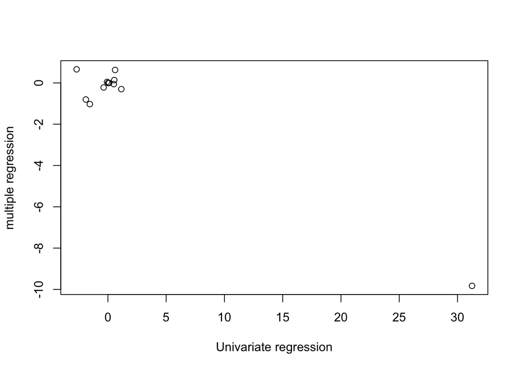

   ```r
   plot(sapply(fits, function(x) coef(x)[2]), coef(mfit)[-1],
     xlab = "Univariate regression",
     ylab = "multiple regression"
   )
   ```

   ```r
   pred <- subset(pred, select = -chas)
   fits <- lapply(names(pred), function(p) {
     f <- paste0("crim ~ poly(", p, ", 3)")
     lm(as.formula(f), data = Boston)
   })
   for (fit in fits) printCoefmat(coef(summary(fit)))
   ```

   ```
                  Estimate Std. Error t value  Pr(>|t|)
   (Intercept)     3.61352    0.33678 10.7296 < 2.2e-16 ***
   poly(obs, 3)1  78.75005    7.57573 10.3950 < 2.2e-16 ***
   poly(obs, 3)2  20.64659    7.57573  2.7254  0.006647 **
   poly(obs, 3)3 -43.87174    7.57573 -5.7911 1.234e-08 ***
   ---
   Signif. codes:  0 '***' 0.001 '**' 0.01 '*' 0.05 '.' 0.1 ' ' 1
                 Estimate Std. Error t value  Pr(>|t|)
   (Intercept)    3.61352    0.37219  9.7088 < 2.2e-16 ***
   poly(zn, 3)1 -38.74984    8.37221 -4.6284 4.698e-06 ***
   poly(zn, 3)2  23.93983    8.37221  2.8594  0.004421 **
   poly(zn, 3)3 -10.07187    8.37221 -1.2030  0.229539
   ---
   Signif. codes:  0 '***' 0.001 '**' 0.01 '*' 0.05 '.' 0.1 ' ' 1
                   Estimate Std. Error t value  Pr(>|t|)
   (Intercept)       3.6135     0.3300 10.9501 < 2.2e-16 ***
   poly(indus, 3)1  78.5908     7.4231 10.5873 < 2.2e-16 ***
   poly(indus, 3)2 -24.3948     7.4231 -3.2863  0.001086 **
   poly(indus, 3)3 -54.1298     7.4231 -7.2920 1.196e-12 ***
   ---
   Signif. codes:  0 '***' 0.001 '**' 0.01 '*' 0.05 '.' 0.1 ' ' 1
                  Estimate Std. Error t value  Pr(>|t|)
   (Intercept)     3.61352    0.32157 11.2370 < 2.2e-16 ***
   poly(nox, 3)1  81.37202    7.23361 11.2492 < 2.2e-16 ***
   poly(nox, 3)2 -28.82859    7.23361 -3.9854 7.737e-05 ***
   poly(nox, 3)3 -60.36189    7.23361 -8.3446 6.961e-16 ***
   ---
   Signif. codes:  0 '***' 0.001 '**' 0.01 '*' 0.05 '.' 0.1 ' ' 1
                Estimate Std. Error t value  Pr(>|t|)
   (Intercept)    3.6135     0.3703  9.7584 < 2.2e-16 ***
   poly(rm, 3)1 -42.3794     8.3297 -5.0878 5.128e-07 ***
   poly(rm, 3)2  26.5768     8.3297  3.1906  0.001509 **
   poly(rm, 3)3  -5.5103     8.3297 -0.6615  0.508575
   ---
   Signif. codes:  0 '***' 0.001 '**' 0.01 '*' 0.05 '.' 0.1 ' ' 1
                 Estimate Std. Error t value  Pr(>|t|)
   (Intercept)    3.61352    0.34852 10.3683 < 2.2e-16 ***
   poly(age, 3)1 68.18201    7.83970  8.6970 < 2.2e-16 ***
   poly(age, 3)2 37.48447    7.83970  4.7814 2.291e-06 ***
   poly(age, 3)3 21.35321    7.83970  2.7237   0.00668 **
   ```

   [output cut: 29 more lines]

   ```
   Signif. codes:  0 '***' 0.001 '**' 0.01 '*' 0.05 '.' 0.1 ' ' 1
                    Estimate Std. Error t value Pr(>|t|)
   (Intercept)       3.61352    0.33917 10.6540   <2e-16 ***
   poly(lstat, 3)1  88.06967    7.62944 11.5434   <2e-16 ***
   poly(lstat, 3)2  15.88816    7.62944  2.0825   0.0378 *
   poly(lstat, 3)3 -11.57402    7.62944 -1.5170   0.1299
   ---
   Signif. codes:  0 '***' 0.001 '**' 0.01 '*' 0.05 '.' 0.1 ' ' 1
                   Estimate Std. Error t value  Pr(>|t|)
   (Intercept)      3.61352    0.29203  12.374 < 2.2e-16 ***
   poly(medv, 3)1 -75.05761    6.56915 -11.426 < 2.2e-16 ***
   poly(medv, 3)2  88.08621    6.56915  13.409 < 2.2e-16 ***
   poly(medv, 3)3 -48.03343    6.56915  -7.312 1.047e-12 ***
   ---
   Signif. codes:  0 '***' 0.001 '**' 0.01 '*' 0.05 '.' 0.1 ' ' 1
   ```

   **Solution** Based on the above summary plot, there are many variables which have non-linearity. For variable `zn`, `rm`, `rad`, `tax`, and `lstat`, the squared coefficient is significant. For variable `indus`, `nox`, `age`, `dis`, `ptratio` and `medv` , the quadratic coefficient is significant.

## 7 Bonus question (20% pts)

For multiple linear regression, show that $R^2$ is equal to the correlation between the response vector $\mathbf{y} = (y_1, \ldots, y_n)^T$ and the fitted values $\hat{\mathbf{y}} = (\hat y_1, \ldots, \hat y_n)^T$. That is
$$R^2 = 1 - \frac{\text{RSS}}{\text{TSS}} = [\operatorname{Cor}(\mathbf{y}, \hat{\mathbf{y}})]^2$$
**Solution** In multiple linear regression, the **RSS** (residual sum of squares) and **TSS**(total sum of squares), and **ESS** (explained sum of square) can be written as:

$$\begin{gather}
\text{RSS} = \sum_{i=1}^n (y_i - \hat{y}_i)^2 \\
\text{TSS} = \sum_{i=1}^n (y_i - \bar{y})^2 \\
\text{ESS} = \sum_{i=1}^n (\hat{y}_i - \bar{y})^2 \\
and\:\: \text{TSS} = \text{ESS}+\text{RSS}
\end{gather}$$

Note that **TSS** can be decomposed into the sum of **ESS** and **RSS** because the observed $y$ is split into the fitted values $\hat{y}$ and the residuals.

Alternatively, $R^2$ measures the proportion of the total variability in $\mathbf{y}$ that is explained by the regression model, which can also be written as:

$$\begin{gather}
R^2 = 1 - \frac{\text{RSS}}{\text{TSS}} \\
= \frac{\text{TSS}}{\text{TSS}} - \frac{\text{RSS}}{\text{TSS}} \\
= \frac{\text{ESS}}{\text{TSS}}
\end{gather}$$

On the other hand, the squared correlation can be decomposed as covariance over variance:

$$[\operatorname{Cor}(\mathbf{y}, \hat{\mathbf{y}})]^2 = \frac{\operatorname{Cov}(\mathbf{y}, \hat{\mathbf{y}})^2}{\operatorname{Var}(\mathbf{y}) \cdot \operatorname{Var}(\hat{\mathbf{y}})}$$

The covariance between $\mathbf{y}$ and $\hat{\mathbf{y}}$ , in this case, $\operatorname{Cov}(\mathbf{y}, \hat{\mathbf{y}})$ can be written as $\operatorname{Var}(\hat{\mathbf{y}})$ since the fitted values $\hat{\mathbf{y}}$ are linear combinations of $\mathbf{y}$ ($\hat{\mathbf{y}}=X\hat{\mathbf{\beta}}$

$$\begin{gather}
\operatorname{Cov}(\mathbf{y}, \hat{\mathbf{y}}) = \frac{1}{n} \sum_{i=1}^n (y_i - \bar{y})(\hat{y}_i - \bar{y}) \\
= \operatorname{Var}(\hat{\mathbf{y}}) = \frac{\text{ESS}}{n}
\end{gather}$$

Given that:

$$\operatorname{Cov}(\mathbf{y}, \hat{\mathbf{y}}) = \frac{\text{ESS}}{n}, \operatorname{Var}(\mathbf{y}) = \frac{\text{TSS}}{n}, \operatorname{Var}(\hat{\mathbf{y}}) = \frac{\text{ESS}}{n}$$

We can substitute covariance and variance in terms of:

$$\begin{gather}
[\operatorname{Cor}(\mathbf{y}, \hat{\mathbf{y}})]^2 = \frac{\operatorname{Cov}(\mathbf{y}, \hat{\mathbf{y}})^2}{\operatorname{Var}(\mathbf{y}) \cdot \operatorname{Var}(\hat{\mathbf{y}})}\\
= \frac{\left(\frac{\text{ESS}}{n}\right)^2}{\left(\frac{\text{TSS}}{n}\right) \cdot \left(\frac{\text{ESS}}{n}\right)} \\
= \frac{\text{ESS}}{\text{TSS}}
\end{gather}$$

Since $R^2 = \frac{\text{ESS}}{\text{TSS}}$ , we can conclude that $R^2 = 1 - \frac{\text{RSS}}{\text{TSS}} = [\operatorname{Cor}(\mathbf{y}, \hat{\mathbf{y}})]^2$